# Mapping the World

Using the sf and spData libraries to create simple maps of the Earth

Isaac Rand

9 April 2020

## R Setup

### Version

This tutorial was generated using the R version 3.5.3, using a different version may lead to unforeseen issues. You can check your version using output of the code chunk below.

```r
version
```

```
##                _
## platform       x86_64-w64-mingw32
## arch           x86_64
## os             mingw32
## system         x86_64, mingw32
## status
## major          3
## minor          5.3
## year           2019
## month          03
## day            11
## svn rev        76217
## language       R
## version.string R version 3.5.3 (2019-03-11)
## nickname       Great Truth
```

### Libraries

To follow along and make your own map of a world or countries within it, you will need to load several R libraries.

If this is your first time using them, you will need to install them first using:

```r
# if you don't need to install packages skip this part :)

install.packages("sf")
install.packages("spData")
```

Now that the packages are installed, load them now. This will step will need to be repeated every time you begin a new R session

```r
library(sf)
library(spData)
```

## Mapping the World

The spData library comes preloaded with an object called `world`. Each row of this object represents a country, complete with its geometry and several pieces of information about it.

Running `plot(world)` generates, by default, maps of only the first 9 attributes listed for each country (you can change this by running `max.plot = your_desired_number`).

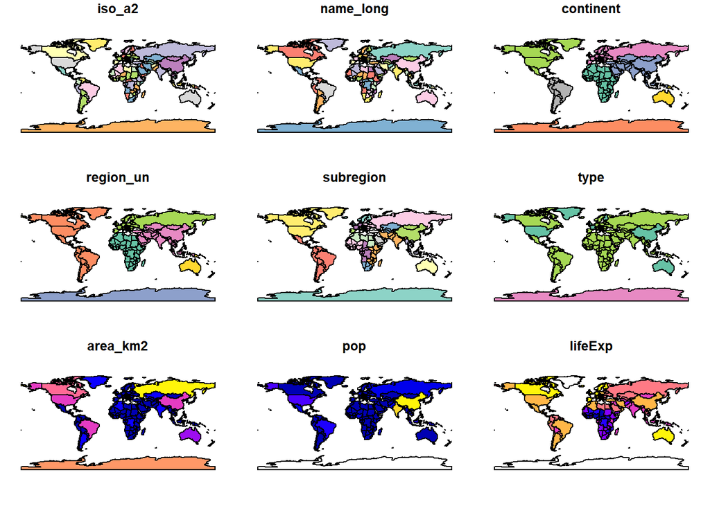

```r
plot(world)
```

Most of the time, we will want to highlight a single variable, not all of them at once. You can select a single variable to plot by appending `["variable_name"]` to the geometry object, as shown below.

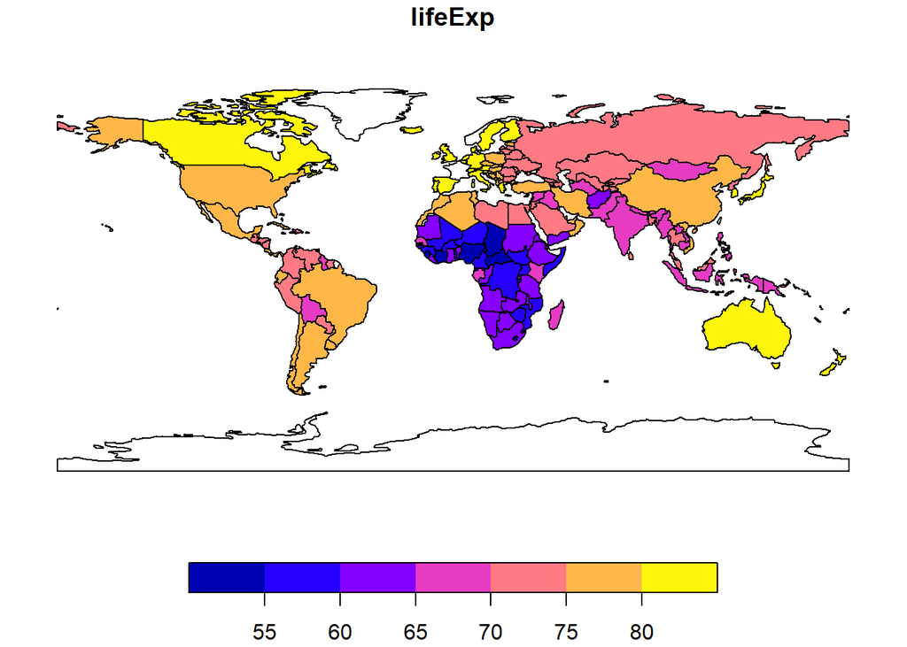

```r
plot(world["lifeExp"])
```

This method can be used to make simple maps of any of the attributes stored in `world`,including any attributes which you add yourself! Additionally, very similar methods can be used to plot any `sfg` object which you can create yourself or import from a spatial file. You can learn more about creating `sfg` objects in section 2.2.6 of Robin Lovelace’s [Geocomputation with R](https://geocompr.robinlovelace.net/spatial-class.html).